# DATA607PROJECTCODE

Samantha Mesa

2026-10-10

## Approach

Hello Professor, This my approach for the three dataset I have choose, my first one is dataset looking at inflation on the USA, the second dataset is new york dispole incone and lastly the third dataset just a zillow home value in the USA dataset. Here are the approaches and challenges for each one

1.USA Inflation: Tracking the 2021–2022 Inflation Spike and Cleaning Messy Monthly Data

Questions: how fast did inflation rise and fall in 2021–2022, and is the annual average hiding timing, as in your post?

Challenges: Text in number columns: “Avail. Oct. 14” and “– (*)” make R read the whole column as text. Read everything as text first, then convert. Ave column: it’s in the same table as the months. If you pivot it with them, it looks like a 13th month. Split it out. October 2025 gap: don’t fill it in. Explain why it’s missing. Page changes: the site updates monthly, so the CSV may not match the page later. Say the date you copied it.

2.BEA New York Income Distribution: Measuring Who Holds New York’s Disposable Income, 2012–2024

Questions: how is disposable income divided across households, did the shares change from 2012 to 2024, and what do taxes do to the top group’s share?

Challenges: Two header rows: the original has “ranked by personal income” and “ranked by disposable income” above the quintile columns. One CSV header can’t hold both, so I put the ranking in the column names, and your pivot_longer() has to split it back out with names_pattern. Mixed row types: one row per year holds dollar ranges as text, not shares. Suppressed values: the 2023 and 2024 component shares are “……..”. Keep them as missing, don’t zero them. 2020 sample size: BEA says the 2020 survey sample is smaller, so be careful about calling 2020 a real change. Units: shares versus percent, and nominal dollars, need clear labels.

3.Zillow Home Values: Comparing New York State Home Value Growth Against the USA.

Questions: how do New York State metros compare with the U.S. in home value level and growth, before and after early 2020?

Challenges: The file is very wide, with 320 monthly columns that become about 286,000 rows after pivoting (before missing values are removed), so I print summaries instead of the whole table. Many smaller metros have blank cells for early months because Zillow didn’t publish a value. I kept these as missing, counted them, and removed them from the tidy table without filling anything in. To keep small metros from skewing the results, I compare growth only where both dates have values. The U.S. row sits with the metros, and metros that span several states are labeled by one state. The values are nominal dollars, not adjusted for inflation, so growth includes general price increases and is not “real” growth. Zillow updates the file monthly, so I note the download date.

## CODE

```r
library(readr)
library(dplyr)
```

```r
library(tidyr)
library(stringr)
library(ggplot2)
library(knitr)
knitr::opts_chunk$set(warning = FALSE)
# No step in this analysis is random, but a global seed is set anyway
# so the document stays reproducible if randomness is added later.
set.seed(42)

# Shared visual style: one theme and one color palette used in every figure
pal <- c(
  "Pre-spike (2000-2020)"  = "#0072B2",
  "Spike (2021-2022)"      = "#D55E00",
  "Post-spike (2023-2026)" = "#009E73"
)

theme_proj <- theme_minimal(base_size = 12) +
  theme(
    plot.title      = element_text(face = "bold"),
    legend.position = "bottom"
  )
theme_set(theme_proj)
```

# 1. Data source/Data structure before tidying

The data come from the U.S. Inflation Calculator page [Current U.S. Inflation Rates (2000-2026)](https://www.usinflationcalculator.com/inflation/current-inflation-rates/). The site republishes figures from the **U.S. Bureau of Labor Statistics (BLS)**: the Consumer Price Index for All Urban Consumers (CPI-U), all items, U.S. city average, **not seasonally adjusted**. Each monthly value is the **12-month percent change** in the CPI (for example, the January 2024 value compares January 2024 with January 2023).

How I obtained the data:

- On October 5, 2026, I copied the table of annual inflation rates (rows 2000 to 2026, columns Jan to Dec plus `Ave`) into a CSV file, `inflation_wide.csv`, **exactly as displayed**, including the non-numeric cells. Nothing was tidied at this stage.
- The CSV is stored in my public GitHub repository, and the code below reads it directly from its web address so the document is reproducible on any computer.
- Two cells are not numbers. October 2025 shows `– (*)` because the BLS did not publish that month’s data (2025 lapse in appropriations). September 2026 shows `Avail. Oct. 14` because that release had not happened yet when I copied the table.

```r
# Every column is read as text so that no value is silently coerced or lost
# on import. Numeric conversion happens explicitly in Section 3.
# The raw file is read from the public GitHub repository (not from a local folder),
# so the code runs the same way on any computer.
raw_url <- "https://raw.githubusercontent.com/Sampro24/DATA607Homeworks/main/inflation_wide.csv"

raw_data <- read_csv(
  raw_url,
  col_types      = cols(.default = col_character()),
  show_col_types = FALSE
)

tibble(rows = nrow(raw_data), columns = ncol(raw_data)) |>
  kable(caption = "Dimensions of the raw wide table")
```

Dimensions of the raw wide table

| rows | columns |
| --- | --- |
| 27 | 14 |

```r
tibble(column_names = names(raw_data)) |>
  kable(caption = "Column names in the raw file")
```

Column names in the raw file

| column_names |
| --- |
| Year |
| Jan |
| Feb |
| Mar |
| Apr |
| May |
| Jun |
| Jul |
| Aug |
| Sep |
| Oct |
| Nov |
| Dec |
| Ave |

The table is wide for three reasons: each month is its own column, the annual average (`Ave`) sits beside the monthly values even though it is a different kind of measurement, and some cells hold text instead of numbers.

```r
# Representative sample: the two most recent years show every kind of messy cell
raw_data |>
  filter(Year %in% c(2026, 2025, 2022)) |>
  kable(caption = "Sample of the raw data (2026, 2025 and 2022)")
```

Sample of the raw data (2026, 2025 and 2022)

| Year | Jan | Feb | Mar | Apr | May | Jun | Jul | Aug | Sep | Oct | Nov | Dec | Ave |
| --- | --- | --- | --- | --- | --- | --- | --- | --- | --- | --- | --- | --- | --- |
| 2026 | 2.4 | 2.4 | 3.3 | 3.8 | 4.2 | 3.5 | 3.4 | 3.4 | Avail. Oct. 14 | NA | NA | NA | NA |
| 2025 | 3.0 | 2.8 | 2.4 | 2.3 | 2.4 | 2.7 | 2.7 | 2.9 | 3.0 | – (*) | 2.7 | 2.7 | 2.6 |
| 2022 | 7.5 | 7.9 | 8.5 | 8.3 | 8.6 | 9.1 | 8.5 | 8.3 | 8.2 | 7.7 | 7.1 | 6.5 | 8.0 |

# 2. Transformation steps

The pipeline runs top to bottom from a clean R session with no manual intervention. Each step says what it does and why.

**Step 2A: Rename variables.** Names are converted to lowercase `snake_case`, the convention used for every column from here on. `Ave` becomes `avg_annual`, and `Year` becomes `year`.

```r
wide_data <- raw_data |>
  rename_with(tolower) |>
  rename(avg_annual = ave) |>
  mutate(year = as.integer(year))

names(wide_data)
```

```
##  [1] "year"       "jan"        "feb"        "mar"        "apr"
##  [6] "may"        "jun"        "jul"        "aug"        "sep"
## [11] "oct"        "nov"        "dec"        "avg_annual"
```

**Step 2B: Reshape from wide to long.** Every column except `year` is stacked into a `period` / `value_raw` pair. The values stay as text for now, so that the cleaning rules in Step 2D are explicit and documented.

```r
long_all <- wide_data |>
  pivot_longer(
    cols      = -year,
    names_to  = "period",
    values_to = "value_raw"
  )

head(long_all, 8) |> kable(caption = "First rows after pivot_longer()")
```

First rows after pivot_longer()

| year | period | value_raw |
| --- | --- | --- |
| 2026 | jan | 2.4 |
| 2026 | feb | 2.4 |
| 2026 | mar | 3.3 |
| 2026 | apr | 3.8 |
| 2026 | may | 4.2 |
| 2026 | jun | 3.5 |
| 2026 | jul | 3.4 |
| 2026 | aug | 3.4 |

**Step 2C: Normalize the variable structure.** The stacked data mix two different kinds of observation: a monthly 12-month rate (one per year and month) and an annual average (one per year). Keeping them in the same column would break the rule that each row is one observation of one kind. They are therefore split into two tidy tables that can be joined on `year`.

```r
annual_raw  <- long_all |> filter(period == "avg_annual") |> select(year, value_raw)
monthly_raw <- long_all |> filter(period != "avg_annual") |> rename(month = period)
```

**Step 2D: Handle missing and inconsistent values.** Three kinds of cell are not numeric. The decisions are documented in the table below and applied by `classify_cell()`:

| Raw cell | Meaning | Decision |
| --- | --- | --- |
| `Avail. Oct. 14` or blank | Release has not happened yet | `rate_pct = NA`, `status = "pending_release"` |
| `– (*)` | BLS did not publish (2025 appropriations lapse) | `rate_pct = NA`, `status = "not_published"` |
| A number written as text | Observed value | Convert to numeric, `status = "observed"` |

No value is imputed or interpolated. Filling in October 2025 would invent a statistic that the BLS never published. The rows are kept (rather than dropped with `drop_na()`) so the gaps remain visible, and analyses filter on `!is.na(rate_pct)`.

```r
# Classify each raw text cell into one of four statuses
classify_cell <- function(x) {
  case_when(
    is.na(x) | str_trim(x) == ""                          ~ "pending_release",
    str_detect(x, "^\\s*-?[0-9]+(\\.[0-9]+)?\\s*$")       ~ "observed",
    str_detect(x, regex("avail", ignore_case = TRUE))     ~ "pending_release",
    str_detect(x, fixed("(*)"))                           ~ "not_published",
    TRUE                                                  ~ "unparsed"
  )
}

monthly_data <- monthly_raw |>
  mutate(
    status   = classify_cell(value_raw),
    # suppressWarnings(): non-numeric text becomes NA by design, and is
    # already labeled in `status`
    rate_pct = if_else(
      status == "observed",
      suppressWarnings(as.numeric(str_trim(value_raw))),
      NA_real_
    ),
    month     = factor(str_to_title(month), levels = month.abb),
    month_num = as.integer(month),
    date      = as.Date(sprintf("%d-%02d-01", year, month_num))
  ) |>
  select(year, month, month_num, date, rate_pct, status) |>
  arrange(date)

annual_data <- annual_raw |>
  mutate(
    status       = classify_cell(value_raw),
    avg_rate_pct = if_else(
      status == "observed",
      suppressWarnings(as.numeric(str_trim(value_raw))),
      NA_real_
    )
  ) |>
  select(year, avg_rate_pct, status)

# Integrity checks: the reshape kept every cell, and no text cell is unexplained
stopifnot(
  nrow(monthly_data) == nrow(raw_data) * 12,
  nrow(annual_data)  == nrow(raw_data),
  !any(monthly_data$status == "unparsed"),
  !any(annual_data$status  == "unparsed")
)

monthly_data |>
  count(status, name = "cells") |>
  kable(caption = "Monthly cells by status")
```

Monthly cells by status

| status | cells |
| --- | --- |
| not_published | 1 |
| observed | 319 |
| pending_release | 4 |

```r
monthly_data |>
  filter(status != "observed") |>
  kable(caption = "Monthly cells without a numeric value")
```

Monthly cells without a numeric value

| year | month | month_num | date | rate_pct | status |
| --- | --- | --- | --- | --- | --- |
| 2025 | Oct | 10 | 2025-10-01 | NA | not_published |
| 2026 | Sep | 9 | 2026-09-01 | NA | pending_release |
| 2026 | Oct | 10 | 2026-10-01 | NA | pending_release |
| 2026 | Nov | 11 | 2026-11-01 | NA | pending_release |
| 2026 | Dec | 12 | 2026-12-01 | NA | pending_release |

**Step 2E: Add an analysis period.** Each month is assigned to the period before, during or after the 2021 to 2022 inflation spike, which is used in the analysis.

```r
tidy_data <- monthly_data |>
  mutate(
    period = case_when(
      date <  as.Date("2021-01-01") ~ "Pre-spike (2000-2020)",
      date <= as.Date("2022-12-01") ~ "Spike (2021-2022)",
      TRUE                          ~ "Post-spike (2023-2026)"
    ),
    period = factor(period, levels = names(pal))
  )

glimpse(tidy_data)
```

```
## Rows: 324
## Columns: 7
## $ year      <int> 2000, 2000, 2000, 2000, 2000, 2000, 2000, 2000, 2000, 2000, …
## $ month     <fct> Jan, Feb, Mar, Apr, May, Jun, Jul, Aug, Sep, Oct, Nov, Dec, …
## $ month_num <int> 1, 2, 3, 4, 5, 6, 7, 8, 9, 10, 11, 12, 1, 2, 3, 4, 5, 6, 7, …
## $ date      <date> 2000-01-01, 2000-02-01, 2000-03-01, 2000-04-01, 2000-05-01,…
## $ rate_pct  <dbl> 2.7, 3.2, 3.8, 3.1, 3.2, 3.7, 3.7, 3.4, 3.5, 3.4, 3.4, 3.4, …
## $ status    <chr> "observed", "observed", "observed", "observed", "observed", …
## $ period    <fct> Pre-spike (2000-2020), Pre-spike (2000-2020), Pre-spike (200…
```

The result is `tidy_data`: one row per year and month, with one column per variable (`year`, `month`, `month_num`, `date`, `rate_pct`, `status`, `period`). The annual averages are in `annual_data`. All analysis below uses only these two tidy tables.

# 3. Analytical methods

The analysis is descriptive. The questions come from my Discussion 5A post:

1. **Before and after the spike.** Summary statistics (count, mean, median, standard deviation, minimum, maximum) of the 12-month rate for each period, plus a time-series line chart of the full monthly series to show how quickly the rate rose and fell.
2. **December versus annual average.** For each year with both values, compare the December 12-month rate with the BLS annual average and compute the gap in percentage points (pp). This shows how much year-to-year movement the annual average hides.
3. **Seasonal pattern.** For each complete year (2000 to 2024), subtract that year’s mean rate from each month, then average these deviations by calendar month. A positive value means that month tends to run above its own year’s average.
4. **Other views.** A heatmap of all months, a box plot of the rate within each period, and a bar chart of the annual average compared with 2%. These show the same tidy data from different angles and add no new calculations beyond medians and standard deviations.

Months without a numeric value are excluded from every calculation.

## 3.A Before and after the 2021 to 2022 spike

```r
period_summary <- tidy_data |>
  filter(!is.na(rate_pct)) |>
  group_by(period) |>
  summarise(
    months     = n(),
    mean_pct   = mean(rate_pct),
    median_pct = median(rate_pct),
    sd_pp      = sd(rate_pct),
    min_pct    = min(rate_pct),
    max_pct    = max(rate_pct),
    .groups    = "drop"
  )

period_summary |>
  kable(
    digits    = 2,
    col.names = c("Period", "Months observed", "Mean (%)", "Median (%)",
                  "Std. dev. (pp)", "Min (%)", "Max (%)"),
    caption   = "12-month inflation rate by period"
  )
```

12-month inflation rate by period

| Period | Months observed | Mean (%) | Median (%) | Std. dev. (pp) | Min (%) | Max (%) |
| --- | --- | --- | --- | --- | --- | --- |
| Pre-spike (2000-2020) | 252 | 2.13 | 2.1 | 1.24 | -2.1 | 5.6 |
| Spike (2021-2022) | 24 | 6.36 | 6.9 | 2.19 | 1.4 | 9.1 |
| Post-spike (2023-2026) | 43 | 3.28 | 3.1 | 0.89 | 2.3 | 6.4 |

```r
# Values referenced in the narrative below
p_mean  <- setNames(round(period_summary$mean_pct, 2), period_summary$period)
peak    <- tidy_data |> slice_max(rate_pct, n = 1)
trough  <- tidy_data |> slice_min(rate_pct, n = 1)
r_jan21 <- tidy_data |> filter(date == as.Date("2021-01-01")) |> pull(rate_pct)
r_jun23 <- tidy_data |> filter(date == as.Date("2023-06-01")) |> pull(rate_pct)
```

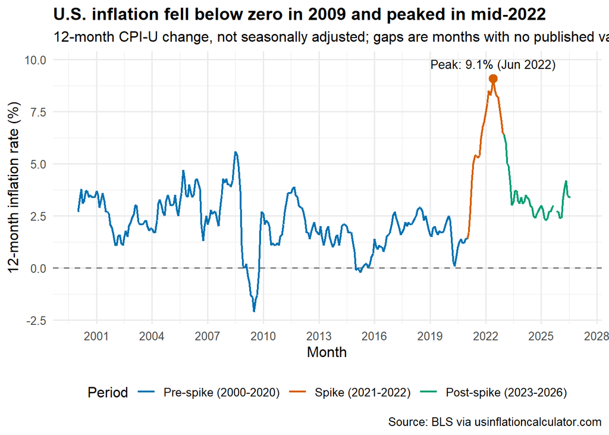

```r
ggplot(tidy_data, aes(x = date, y = rate_pct, color = period, group = 1)) +
  geom_hline(yintercept = 0, linetype = "dashed", color = "grey50") +
  geom_line(linewidth = 0.8) +
  geom_point(data = peak, size = 3, show.legend = FALSE) +
  annotate(
    "text",
    x = peak$date, y = peak$rate_pct + 0.7,
    label = sprintf("Peak: %.1f%% (%s)", peak$rate_pct, format(peak$date, "%b %Y")),
    size = 3.5
  ) +
  scale_color_manual(values = pal, name = "Period") +
  scale_x_date(date_breaks = "3 years", date_labels = "%Y") +
  labs(
    title    = "U.S. inflation fell below zero in 2009 and peaked in mid-2022",
    subtitle = "12-month CPI-U change, not seasonally adjusted; gaps are months with no published value",
    x        = "Month",
    y        = "12-month inflation rate (%)",
    caption  = "Source: BLS via usinflationcalculator.com"
  )
```

Before 2021 the 12-month rate averaged 2.13%. During the spike it averaged 6.36%, and in the post-spike months it averaged 3.28%, which is above the pre-spike average, so inflation has not returned to its earlier norm. The rate climbed from 1.4% in January 2021 to a peak of 9.1% in June 2022, a rise of 7.7 pp in 17 months. It then fell to 3% by June 2023, a drop of 6.1 pp in only 12 months. The decline was faster than the climb. The lowest rate in the whole series is -2.1% in July 2009. The gap in the line at October 2025 is the month the BLS did not publish.

## 3.B December versus the annual average

```r
dec_vs_avg <- tidy_data |>
  filter(month == "Dec") |>
  select(year, dec_rate_pct = rate_pct) |>
  inner_join(annual_data |> select(year, avg_rate_pct), by = "year") |>
  filter(!is.na(dec_rate_pct), !is.na(avg_rate_pct)) |>
  mutate(gap_pp = dec_rate_pct - avg_rate_pct)

dec_vs_avg |>
  arrange(desc(abs(gap_pp))) |>
  slice_head(n = 8) |>
  kable(
    digits    = 1,
    col.names = c("Year", "December rate (%)", "Annual average (%)",
                  "Gap: Dec minus average (pp)"),
    caption   = "Eight years where December and the annual average differ most"
  )
```

Eight years where December and the annual average differ most

| Year | December rate (%) | Annual average (%) | Gap: Dec minus average (pp) |
| --- | --- | --- | --- |
| 2008 | 0.1 | 3.8 | -3.7 |
| 2009 | 2.7 | -0.4 | 3.1 |
| 2021 | 7.0 | 4.7 | 2.3 |
| 2022 | 6.5 | 8.0 | -1.5 |
| 2007 | 4.1 | 2.8 | 1.3 |
| 2001 | 1.6 | 2.8 | -1.2 |
| 2014 | 0.8 | 1.6 | -0.8 |
| 2016 | 2.1 | 1.3 | 0.8 |

```r
big_gap <- dec_vs_avg |> slice_max(abs(gap_pp), n = 1)
```

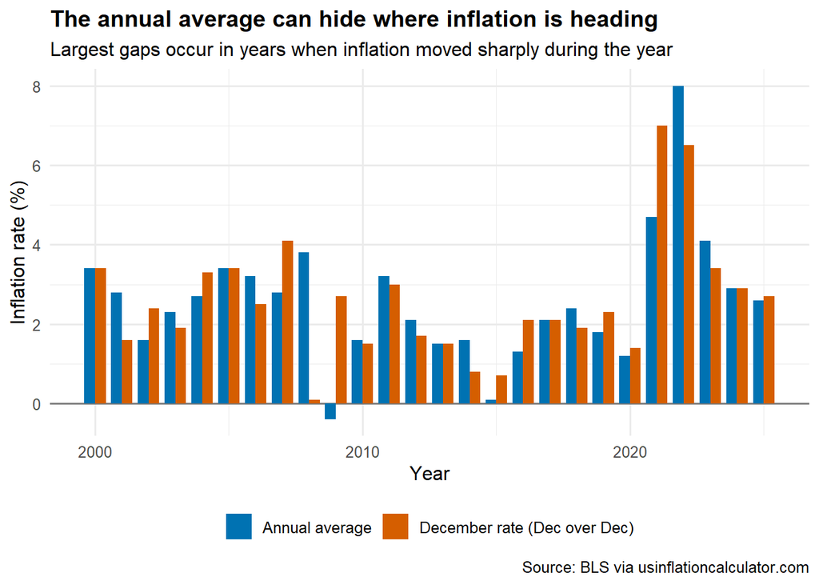

```r
dec_vs_avg |>
  pivot_longer(
    cols      = c(dec_rate_pct, avg_rate_pct),
    names_to  = "measure",
    values_to = "rate_pct"
  ) |>
  mutate(
    measure = recode(
      measure,
      dec_rate_pct = "December rate (Dec over Dec)",
      avg_rate_pct = "Annual average"
    )
  ) |>
  ggplot(aes(x = year, y = rate_pct, fill = measure)) +
  geom_hline(yintercept = 0, color = "grey50") +
  geom_col(position = "dodge", width = 0.8) +
  scale_fill_manual(
    values = c("December rate (Dec over Dec)" = "#D55E00", "Annual average" = "#0072B2"),
    name   = NULL
  ) +
  labs(
    title    = "The annual average can hide where inflation is heading",
    subtitle = "Largest gaps occur in years when inflation moved sharply during the year",
    x        = "Year",
    y        = "Inflation rate (%)",
    caption  = "Source: BLS via usinflationcalculator.com"
  )
```

The two measures often differ because the annual average blends twelve months, while December shows where inflation stood at the end of the year. The largest gap is in 2008: a December rate of 0.1% against an annual average of 3.8%, a difference of -3.7 pp. In the spike years the two measures tell opposite stories: in 2021 December (7.0%) was 2.3 pp above the average (4.7%), because inflation was still accelerating, while in 2022 December (6.5%) was 1.5 pp *below* the average (8.0%), because inflation had already begun to fall.

## 3.C Seasonal pattern

```r
seasonal <- tidy_data |>
  filter(year <= 2024, !is.na(rate_pct)) |>   # complete years only
  group_by(year) |>
  mutate(dev_pp = rate_pct - mean(rate_pct)) |>
  ungroup() |>
  group_by(month) |>
  summarise(mean_dev_pp = mean(dev_pp), .groups = "drop") |>
  mutate(direction = if_else(mean_dev_pp >= 0, "Above yearly mean", "Below yearly mean"))

seasonal |>
  select(month, mean_dev_pp) |>
  kable(
    digits    = 2,
    col.names = c("Month", "Mean deviation from the year's mean (pp)"),
    caption   = "Average deviation by calendar month, 2000 to 2024"
  )
```

Average deviation by calendar month, 2000 to 2024

| Month | Mean deviation from the year’s mean (pp) |
| --- | --- |
| Jan | -0.02 |
| Feb | -0.01 |
| Mar | 0.02 |
| Apr | 0.01 |
| May | 0.02 |
| Jun | 0.02 |
| Jul | 0.01 |
| Aug | 0.00 |
| Sep | -0.01 |
| Oct | -0.03 |
| Nov | -0.03 |
| Dec | -0.01 |

```r
month_hi <- seasonal |> slice_max(mean_dev_pp, n = 1)
month_lo <- seasonal |> slice_min(mean_dev_pp, n = 1)
```

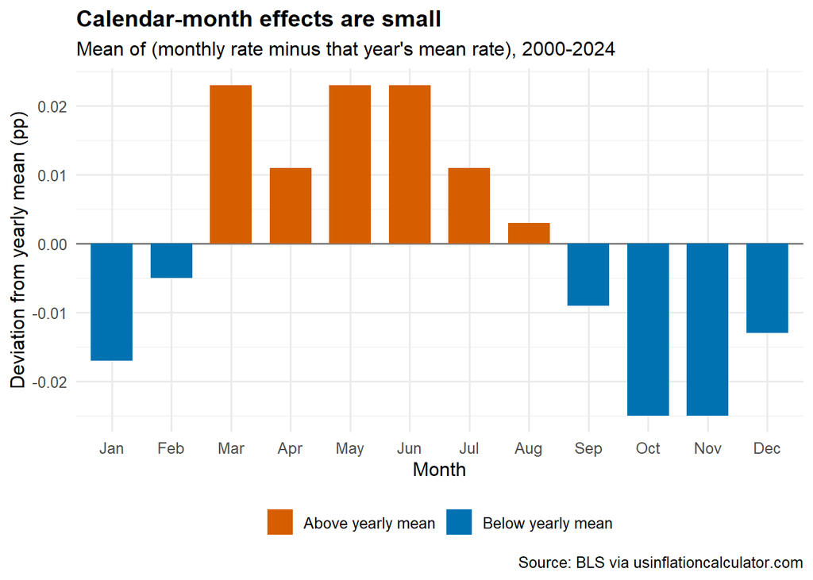

```r
ggplot(seasonal, aes(x = month, y = mean_dev_pp, fill = direction)) +
  geom_hline(yintercept = 0, color = "grey50") +
  geom_col(width = 0.7) +
  scale_fill_manual(
    values = c("Above yearly mean" = "#D55E00", "Below yearly mean" = "#0072B2"),
    name   = NULL
  ) +
  labs(
    title    = "Calendar-month effects are small",
    subtitle = "Mean of (monthly rate minus that year's mean rate), 2000-2024",
    x        = "Month",
    y        = "Deviation from yearly mean (pp)",
    caption  = "Source: BLS via usinflationcalculator.com"
  )
```

The seasonal effect is weak. The highest month is Jun (0.02 pp) and the lowest is Nov (-0.03 pp). This is expected: each value is a *12-month* change, which already removes most seasonality, so what remains mostly reflects the year’s trend (a year in which inflation rises will have higher values late in the year). A seasonal pattern would show up more clearly in the month-over-month, seasonally unadjusted CPI, which this table does not contain.

## 3.D Other views of the same data

Three more charts look at the same tidy data in different ways: a heatmap of every month, a box plot of the rate within each period, and a bar chart of the annual average.

### Heatmap of every month

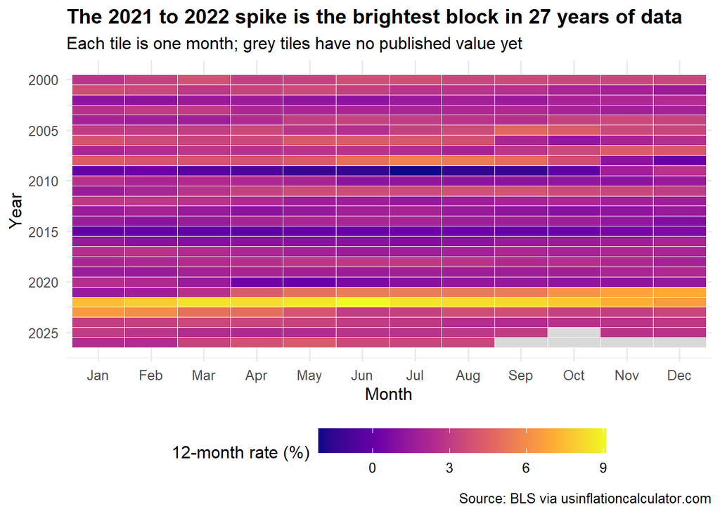

```r
ggplot(tidy_data, aes(x = month, y = year, fill = rate_pct)) +
  geom_tile(color = "white", linewidth = 0.3) +
  scale_fill_viridis_c(
    option   = "plasma",
    name     = "12-month rate (%)",
    na.value = "grey85",
    guide    = guide_colorbar(barwidth = 14)
  ) +
  scale_y_reverse(breaks = seq(2000, 2025, by = 5)) +
  labs(
    title    = "The 2021 to 2022 spike is the brightest block in 27 years of data",
    subtitle = "Each tile is one month; grey tiles have no published value yet",
    x        = "Month",
    y        = "Year",
    caption  = "Source: BLS via usinflationcalculator.com"
  )
```

The heatmap shows the whole series at once. The brightest tiles are the months of 2021 to 2022 (the highest is 9.1% in June 2022), and the darkest are the 2009 months, when the rate was below zero. The grey tiles are the months with no value (October 2025, and September to December 2026).

### Spread within each period

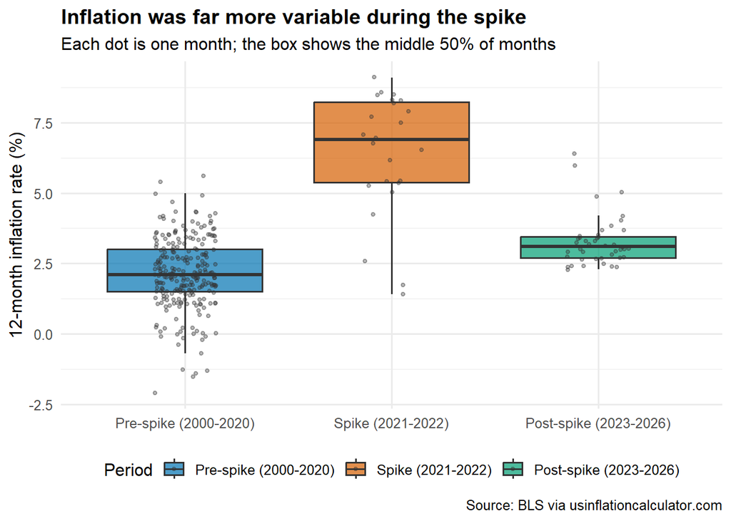

```r
tidy_data |>
  filter(!is.na(rate_pct)) |>
  ggplot(aes(x = period, y = rate_pct, fill = period)) +
  geom_boxplot(alpha = 0.7, outlier.shape = NA) +
  geom_jitter(width = 0.15, alpha = 0.35, size = 1, color = "grey20") +
  scale_fill_manual(values = pal, name = "Period") +
  labs(
    title    = "Inflation was far more variable during the spike",
    subtitle = "Each dot is one month; the box shows the middle 50% of months",
    x        = NULL,
    y        = "12-month inflation rate (%)",
    caption  = "Source: BLS via usinflationcalculator.com"
  )
```

```r
widest <- period_summary |> slice_max(sd_pp, n = 1)
```

The box plot compares the shape of the three periods, not only their averages. The period with the widest spread is Spike (2021-2022) (standard deviation 2.19 pp). Its median (6.9%) is also well above the other periods’ medians.

### Annual averages against the 2% goal

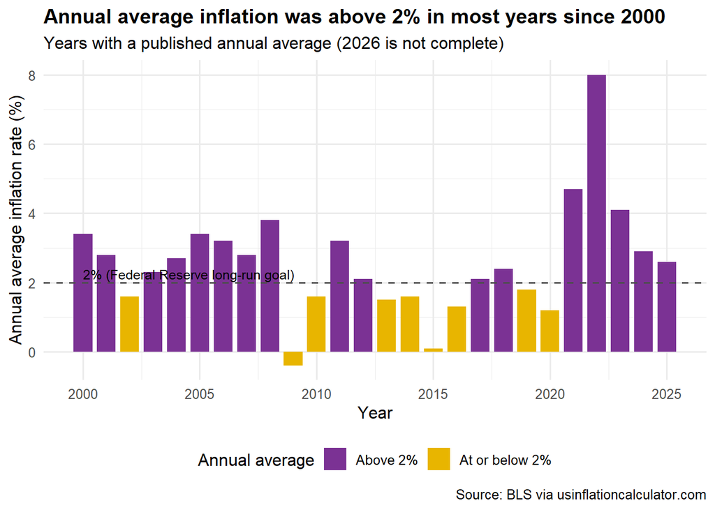

```r
annual_plot <- annual_data |>
  filter(!is.na(avg_rate_pct)) |>
  mutate(
    goal = if_else(avg_rate_pct > 2, "Above 2%", "At or below 2%")
  )

ggplot(annual_plot, aes(x = year, y = avg_rate_pct, fill = goal)) +
  geom_col(width = 0.8) +
  geom_hline(yintercept = 2, linetype = "dashed", color = "grey30") +
  annotate("text", x = 2000, y = 2.25, label = "2% (Federal Reserve long-run goal)",
           hjust = 0, size = 3.3) +
  scale_fill_manual(
    values = c("Above 2%" = "#7B3294", "At or below 2%" = "#E8B500"),
    name   = "Annual average"
  ) +
  scale_x_continuous(breaks = seq(2000, 2025, by = 5)) +
  labs(
    title    = "Annual average inflation was above 2% in most years since 2000",
    subtitle = "Years with a published annual average (2026 is not complete)",
    x        = "Year",
    y        = "Annual average inflation rate (%)",
    caption  = "Source: BLS via usinflationcalculator.com"
  )
```

```r
n_above  <- sum(annual_plot$avg_rate_pct > 2)
n_years  <- nrow(annual_plot)
top_year <- annual_plot |> slice_max(avg_rate_pct, n = 1)
```

The annual average was above 2% in 17 of the 26 years with a published average. The highest was 2022 (8%). The 2% line is the Federal Reserve’s long-run inflation goal, used here as a simple reference point. The Fed’s own target is for a different price measure than the CPI used in this table, so the comparison is only a rough guide.

# 4. Conclusions

- **The 2021 to 2022 spike was large and fast.** The 12-month rate rose from 1.4% in January 2021 to 9.1% in June 2022 and then dropped to 3.0% by June 2023. The descent (6.1 pp in 12 months) was quicker than the climb (7.7 pp in 17 months).
- **Inflation settled above its old norm.** Post-spike months average 3.28% compared with 2.13% before 2021. In 2026 the rate rose again, from 2.4% in January and February to 4.2% in May, before easing to 3.4% in July and August.
- **The annual average hides the timing.** December 2021 was 2.3 pp above that year’s average of 4.7%, and December 2022 was 1.5 pp below the average of 8.0%. The largest gap in the whole series is in 2008 (-3.7 pp). Anyone reading only the annual average would place the peak in 2022 and miss that inflation was already falling by December.
- **Seasonality is weak in this data.** Monthly deviations stay within about 0.03 pp of the yearly mean, because 12-month changes remove most seasonal effects.
- **Limitations.** The series is not seasonally adjusted, October 2025 is missing because of the 2025 lapse in appropriations (it was left as `NA`, not imputed), and September to December 2026 had not been released when the data were collected. The numbers are descriptive and do not explain causes.

## Citation

Anthropic. (2026). Claude (Sonnet 5) [Large language model]. https://claude.ai

I did ask claude to give me other visual, graph to show the data, that what all the graphs from part 3.D are.

```